# Risk-Parity Portfolio

# Inrtoduction

Practical flaws of Markowitz Model:

1.variance is not a good risk measure in practice. The solution is use alternative measure for risk, such as downside risk (VaR, CVaR, Sortino ratio). The theoreticians described a number of properties a good risk measure should satify: **a coherent risk measure**. Such properties include monotonicity, sub-additivity, homogeneity, and translational invariance. *Ref* [coherent risk measure](https://en.wikipedia.org/wiki/Coherent_risk_measure)

2.Sensitivity w.r.t estimators (parameter estimation of covariance matrix and mean vector by using historic data). If we use historic data, we introduce another assumption: no time-varying of estimator(and in practice Smaple size cannot be large enough due to lack of stationarity of data). Some improvements includes modeling $r_t$ conditional on $\mathcal{F_{t-1}}$ and give different weights to observation data like **Garch** model by not assuming that conditional covariance and conditional mean are constant. Solutions include **shrinkage estimators**, **Black-Litterman estimators** (similar to a reverse engineering: do things backwards).

3.Lack of diversification (this seems quite contradictive; but in most case we allocate a large weight to only few assets): concentrates risk too much in few assets (2008 financial crisis): solution is the **risk-parity portfolio**.

### Conclusion

Simply speaking, Markowitz framework is two-objectives optimiation problem: the mean return $\mathbf{w^T}{\boldsymbol{\mu}}$ and the variance $\mathbf{w^T}\mathbf{\Sigma}\mathbf{w^T}$. The idea is to find a trade-off between these two regarding how risk-averse a investor is.

**Risk parity portfolio**

- Less senstive to parameter estimation errors
- Diversifies the risk

# Review: Emprical demonstration of flaws of Markowiz framwork

$$\begin{array}{} \underset{\mathbf{w}}{maximize} & \boldsymbol{\mu}^T - \lambda {\mathbf{w}^T}{\mathbf{\Sigma w}}\\
{subject~ to} &\mathbf{1}^T \mathbf{w} = 1\\
&\mathbf{w}\geqslant 0 \end{array}$$

For convience, we define a function to find the solution using *CVXR* package for convex quadratic optimization problem.

```r
library("CVXR")
weights_Markowitz <- function(lambda, Sigma, mu){

  w <- Variable(length(mu))
  res <- solve(Problem(Maximize(t(mu) %*% w - lambda*quad_form(w, Sigma)),
                       constraints = list(w >= 0, sum(w) == 1)))
  w_Markowitz <- as.matrix(res$getValue(w))
  rownames(w_Markowitz) <- stock_namels
  return(w_Markowitz)
}
```

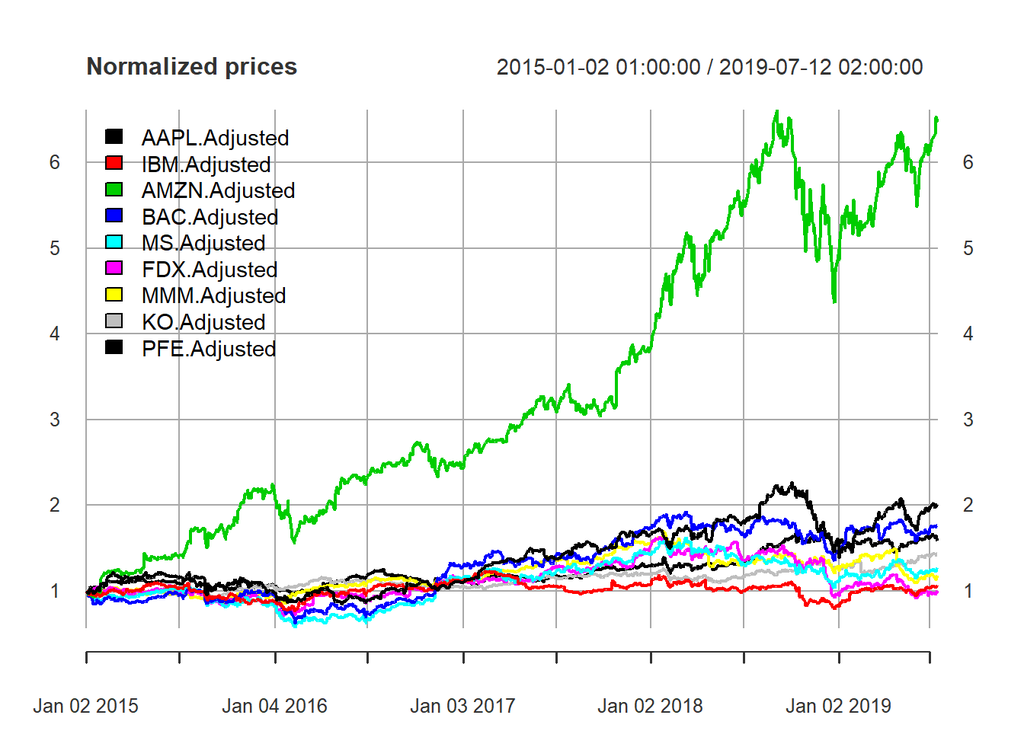

```r
library(xts)
library(quantmod)
begin_date <- "2015-01-01"
end_date <- "2019-07-13"
stock_namels <- c("AAPL", "IBM", "AMZN", "BAC", "MS", "FDX", "MMM", "KO", "PFE")
prices <- xts()
stock = "IBM"
for (stock in stock_namels){
  prices <- cbind(prices, Ad(getSymbols(stock, from = begin_date, to = end_date, auto.assign = FALSE)))
}

plot(prices/rep(prices[1, ], each = nrow(prices)), legend.loc = "topleft",
     main = "Normalized prices")
```

```r
logret <- diff(log(prices))
colnames(logret) <- stock_namels
mu <- colMeans(logret, na.rm = TRUE)
Sigma <- cov(na.omit(logret))
```